# Lab 3: Optimal Harvest

### i. Plot the ‘biology’ and the ‘economics’ as a function of population size. That is, make a plot with N on the x-axis and two lines, one representing the subsidized logistic growth (r*N*(1-N/K) + M), and one representing harvest (q*E*N). For the economics, choose E = E_MSY from your logistic analysis in the first part of this lab.

```r
############################
# 1. biology
############################
r = 0.5
K = 100
M = 10

growth.sub <- (r*Nset*(1-Nset/K) + M)
growth.sub
```

[output not shown]

```r
harvest.sub <- q*(E_MSY)*Nset
harvest.sub
```

[output not shown]

[output cut: 19 more lines]

```r
dndt.sub <- r * Nset * (1 - (Nset / K)) - q * E * Nset + M
dndt.sub
```

[output not shown]

[output cut: 19 more lines]

```r
Y_MSY.sub <- max(dndt.sub)
Y_MSY.sub
```

```
## [1] 17.9998
```

```r
for (i in 1:length(Nset)) {
  if (!is.na(dndt.sub[i]) && dndt.sub[i] == Y_MSY.sub) {
    N_MSY.sub <- Nset[i]
  }
}

N_MSY.sub
```

```
## [1] 39.79899
```

```r
E_MSY.sub <- Y_MSY.sub/q/N_MSY.sub
E_MSY.sub
```

```
## [1] 4.522677
```

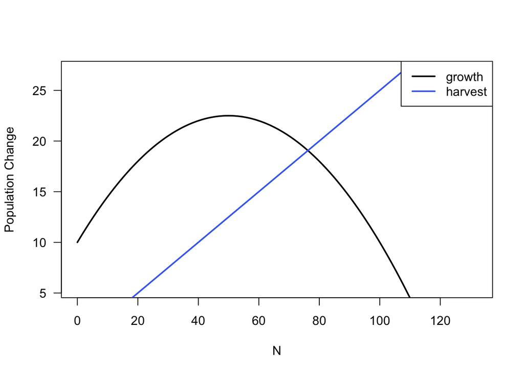

```r
dNdt.log <- r * Nset * (1-Nset/K)
############################################
# 1. plot the biology of logistic growth
############################################
# plot the biology in black
plot(x = Nset, y = growth.sub,
     type = 'l',
     las = 1,
     lwd = 2,
     xlab = 'N', ylab = 'Population Change',
     xlim = c(0, max(Nset) * 1.2),  # Expands the x-axis range
     ylim = c(min(growth.sub) * 1.2, max(growth.sub) * 1.2) )

# plot the x-axis so that it's easier to see the intercept
abline(h = 0, lwd = 1)

############################################
# 2. plot the economics of harvest
############################################
# plot the economics in blue
lines(x = Nset, y = harvest.sub, col = 'royalblue2', lwd = 2)

############################################
# 3. create a legend
############################################
legend("topright",
       lwd = c(2, 2),
       legend = c('growth', 'harvest'),
       col = c('black', 'royalblue2'))
```

/1 point for subsidized stock line  
/1 point for harvest line  
/1 point legend  
/1 point for axes (popn change vs. N)  
= /6 points total

### ii. Does this effort level still yield the maximum sustainable yield?

No it does not

= /1 point total

### iii. If not, adjust effort and report your new E_MSY, N_MSY, and Y_MSY.

```r
Y_MSY.sub <- max(dndt.sub)
Y_MSY.sub
```

```
## [1] 17.9998
```

```r
for (i in 1:length(Nset)) {
  if (!is.na(dndt.sub[i]) && dndt.sub[i] == Y_MSY.sub) {
    N_MSY.sub <- Nset[i]
  }
}

N_MSY.sub
```

```
## [1] 39.79899
```

```r
E_MSY.sub <- Y_MSY.sub/q/N_MSY.sub
E_MSY.sub
```

```
## [1] 4.522677
```

/1 point for N_MSY.sub  
/1 point for E_MSY.sub  
/1 point for Y_MSY.sub  
= /3 points

### iv. Make a new version of your graph from part (i), but using your new E_MSY.

```r
harvest.sub1 <- q*(E_MSY.sub)*Nset
harvest.sub1
```

[output not shown]

[output cut: 19 more lines]

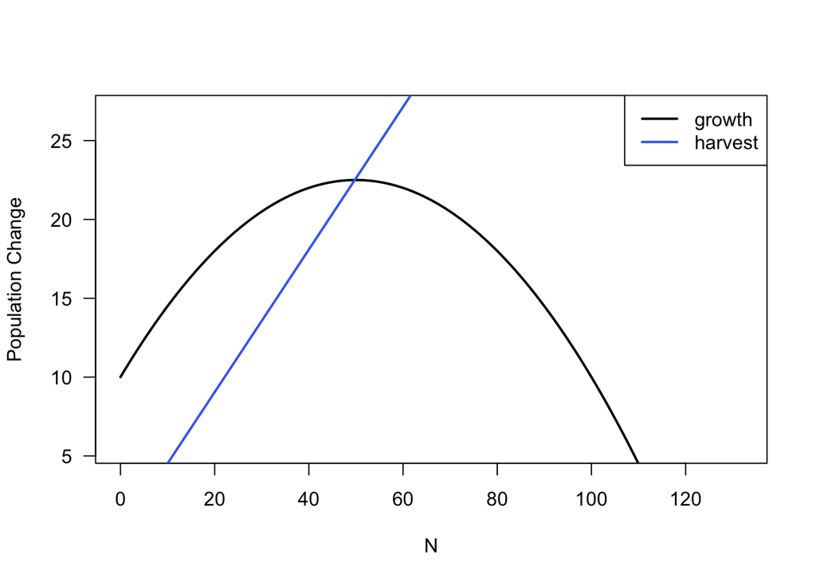

```r
############################################
# 1. plot the biology of logistic growth
############################################
# plot the biology in black
plot(x = Nset, y = growth.sub,
     type = 'l',
     las = 1,
     lwd = 2,
     xlab = 'N', ylab = 'Population Change',
     xlim = c(0, max(Nset) * 1.2),  # Expands the x-axis range
     ylim = c(min(growth.sub) * 1.2, max(growth.sub) * 1.2) )

# plot the x-axis so that it's easier to see the intercept
abline(h = 0, lwd = 1)

############################################
# 2. plot the economics of harvest
############################################
# plot the economics in blue
lines(x = Nset, y = harvest.sub1, col = 'royalblue2', lwd = 2)

############################################
# 3. create a legend
############################################
legend("topright",
       lwd = c(2, 2),
       legend = c('growth', 'harvest'),
       col = c('black', 'royalblue2'))
```

/1 point for subsidized stock line  
/1 point for harvest line with new E_MSY from the subsidized stock analysis  
/1 point for stable equilibrium  
/1 point legend  
/1 point for axes (popn change vs. N)  
= /5 points total

### v. Explain how having the nearby reserve affected the fishery you are managing.

Our E_MSY was suddenly at a smaller population size. Effort increased.

= /2 points total

## 5. Comparison across stocks: Compare N_MSY and E_MSY for the four stocks you’ve studied in this lab. Explain, biologically, why any differences exist.

```r
E_MSY
```

```
## [1] 2.5
```

```r
E_MSY.dep
```

```
## [1] 2.214916
```

```r
E_MSY.over
```

```
## [1] 8.414955e-16
```

```r
E_MSY.sub
```

```
## [1] 4.522677
```

Stocks experiencing higher fishing effort (E) or higher catchability (q) may have a reduced N_MSY. If a fishery is over-exploited, its N_MSY may decline compared to an unfished or lightly fished stock. N_MSY was largest for depensating stocks and smallest for subsidized stocks.

/2 points for N_MSY comparison across logistic, overcompensating, depensating and subsidized stocks  
/2 points for E_MSY comparison across logistic, overcompensating, depensating and subsidized stocks  
= /4 points total